# **Data Understanding**

## **Data Understanding (Pemahaman Data)**

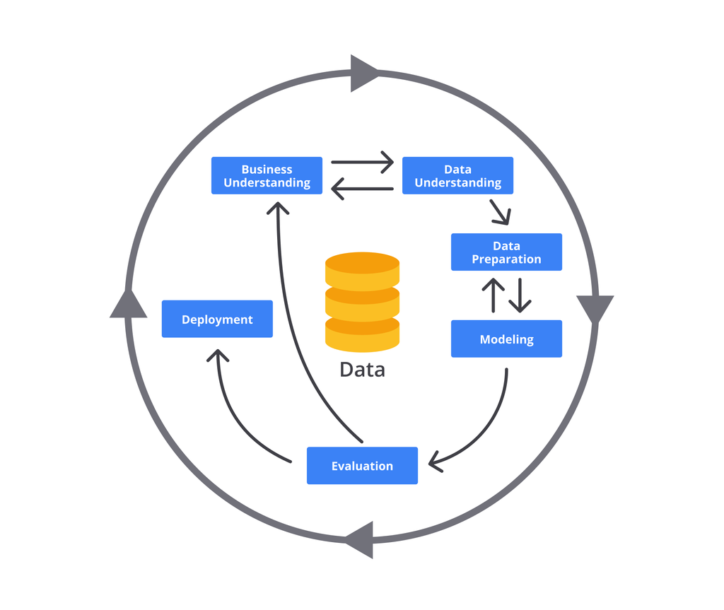

1. **Pengumpulan Data**: Mengumpulkan data dari berbagai sumber yang relevan untuk analisis.
2. **Eksplorasi Data**: Menganalisis data secara visual dan statistik untuk memahami pola, tren, dan hubungan antar variabel.
3. **Pembersihan Data**: Mengidentifikasi dan menangani masalah data seperti missing values, duplikasi, atau kesalahan dalam data.
4. **Identifikasi Variabel Kunci**: Menentukan fitur atau variabel yang memiliki pengaruh besar terhadap tujuan analisis.
5. **Pahami Distribusi Data**: Memeriksa distribusi nilai-nilai variabel untuk memahami sebaran data.

Dengan data yang dipahami dengan baik, analisis berikutnya dapat dilakukan lebih efektif dan menghasilkan insight yang lebih akurat.

### **Langkah-Langkah Dalam Data Understanding**

Berikut adalah langkah-langkah dalam **Data Understanding**:

1. **Pengumpulan Data**:
   - Mengumpulkan data dari berbagai sumber (misalnya, database, file CSV, API, dll.).
   - Memastikan data yang dikumpulkan relevan dengan tujuan analisis.
2. **Eksplorasi Data**:
   - Menggunakan teknik statistik dan visualisasi untuk melihat pola atau hubungan antar variabel.
   - Membuat statistik deskriptif (mean, median, modus, standar deviasi) untuk memahami distribusi data.
   - Menggunakan grafik seperti histogram, boxplot, scatter plot untuk mengeksplorasi hubungan antar data.
3. **Pembersihan Data (Data Cleaning)**:
   - Mengidentifikasi dan menangani nilai yang hilang (missing values) dengan mengganti, menghapus, atau mengimputasi data.
   - Mengidentifikasi dan menghapus duplikasi data jika ada.
   - Menangani data yang tidak konsisten (misalnya, kesalahan penulisan atau format data yang salah).
4. **Identifikasi Outliers**:
   - Mencari nilai ekstrim atau outliers yang bisa mempengaruhi analisis.
   - Menggunakan teknik statistik atau visualisasi (seperti boxplot) untuk mendeteksi outliers.
   - Menentukan apakah outliers perlu dihapus, diperbaiki, atau dibiarkan.
5. **Memahami Struktur Data**:
   - Memeriksa jenis data (numerik, kategorikal, teks) dan hubungan antar variabel.
   - Menyusun data dalam bentuk yang sesuai untuk analisis lebih lanjut (misalnya, mengonversi data kategorikal menjadi format numerik jika diperlukan).
6. **Pemeriksaan Korelasi Antar Variabel**:
   - Menggunakan teknik statistik seperti korelasi Pearson atau Spearman untuk melihat hubungan antara variabel.
   - Menentukan variabel mana yang saling mempengaruhi dan mana yang tidak.
7. **Validasi Sumber Data**:
   - Memastikan bahwa data yang digunakan memiliki kualitas yang baik dan dapat dipercaya.
   - Memeriksa apakah ada bias dalam data yang bisa mempengaruhi hasil analisis.
8. **Dokumentasi Temuan**:
   - Mencatat semua temuan selama eksplorasi data, seperti pola yang ditemukan, masalah yang muncul, dan langkah-langkah pembersihan yang telah dilakukan.
   - Menggunakan dokumentasi ini untuk merencanakan langkah-langkah analisis lebih lanjut.

Setelah langkah-langkah ini selesai, data akan siap untuk diproses lebih lanjut dalam tahap analisis dan modeling.

### **Jenis Tipe di Data Mining**

Ketika kita mempelajari data mining tentunya objek yang paling utama diolah adalah data itu sendiri. Data adalah sekumpulan fakta atau objek dan atributnya. Atribut merupakn karakteristik atau properti dari objek tertentu. Jenis atribut atau nilai dari kolom ada beberapa, diantaranya adalah :

- Nominal yang merupakan kategori class yang tidak memiliki perbedaan nilai atau rangking. Contoh pekerjaan (Dosen, PNS).
- Binary merupakan atribut yang tidak memiliki perbedaan dan hanya memiliki 2 states, contohnya seperti jenis kelamin (perempuan, laki-laki).
- Ordinal merupakan kategori class yang memiliki nilai rangking, contohnya seperti jabatan, jenjang pendidikan, dll.
- Numeric merupakan kuantitas yang memiliki ukuran nilai yang memiliki jarak yang jelas, contohnya adalah umur. Numeric ini memiliki 2 jenis, yaitu rasio dan interval.

## **DBeaver**.

**DBeaver** adalah alat manajemen basis data (database management tool) yang bersifat open-source dan mendukung berbagai jenis database, seperti MySQL, PostgreSQL, SQLite, Oracle, SQL Server, dan lainnya. DBeaver menyediakan antarmuka grafis (GUI) yang memudahkan pengguna untuk melakukan query, eksplorasi data, manajemen skema, dan administrasi database.

### **Fitur Utama DBeaver**

**Dukungan Multi-Database** – Bisa terhubung ke berbagai sistem database.  
**Query Editor** – Mendukung SQL editor dengan fitur auto-complete.  
**ER Diagram** – Bisa menampilkan struktur database dalam bentuk diagram.  
**Data Import/Export** – Mendukung ekspor data ke format seperti CSV, JSON, XML, Excel.  
**Open-Source & Cross-Platform** – Bisa digunakan di Windows, macOS, dan Linux.

DBeaver sering digunakan oleh developer, database administrator (DBA), dan data analyst untuk mengelola database dengan lebih efisien.

### **Berikut langkah-langkah untuk menghubungkan DBeaver ke database:**

Berikut langkah-langkah untuk menghubungkan DBeaver ke database:

### **1. Install DBeaver**

Jika belum memiliki DBeaver, unduh dan instal dari https://dbeaver.io/download/.  
Gunakan **DBeaver Community** (gratis) atau **DBeaver Enterprise** (berbayar jika butuh fitur tambahan).

### **2. Buka DBeaver dan Tambahkan Koneksi Database**

1. **Buka DBeaver** setelah instalasi selesai.
2. Klik **File** → **New** → **Database Connection** atau tekan tombol **Ctrl + N**.
3. Pilih jenis database yang ingin dikoneksikan, misalnya **MySQL, PostgreSQL, atau lainnya**.
4. Klik **Next**.

### **3. Masukkan Detail Koneksi**

1. **Host**: Masukkan alamat server database (contoh: `localhost` atau IP server).
2. **Port**: Gunakan port default atau sesuai konfigurasi (contoh:
   - **MySQL**: `3306`
   - **PostgreSQL**: `5432`
3. **Database Name**: Masukkan nama database yang ingin dihubungkan.
4. **Username & Password**: Masukkan kredensial pengguna database.
5. **Klik "Test Connection"** untuk memastikan koneksi berhasil.
6. Jika diminta, instal driver database dengan menekan tombol **Download Driver**.

### **4. Selesai & Mulai Menggunakan DBeaver**

- Jika koneksi berhasil, klik **Finish**.
- Database akan muncul di panel **Database Navigator** di sisi kiri.
- Sekarang Anda bisa menjalankan **SQL Query**, melihat tabel, mengedit data, dan mengelola database.

Jika Anda menggunakan database di cloud seperti **Aiven.io**, pastikan:  
Anda memiliki **hostname, port, username, dan password** dari Aiven.  
Pastikan server database mengizinkan koneksi dari IP Anda.

Apakah Anda ingin menghubungkan ke **MySQL atau PostgreSQL** di DBeaver

**Contoh di PostgreSQL :**

[figure not shown]

### **fitur dan tools utama yang tersedia di DBeaver:**

1. Database Management Koneksi ke berbagai jenis database (MySQL, PostgreSQL, Oracle, SQL Server, SQLite, dll.) Manajemen koneksi database Eksekusi SQL (Query Editor) Auto-completion SQL Visual query builder
2. Data Tools Data Editor: Menampilkan, mengedit, dan memfilter data dalam tabel Import/Export Data: Dukungan untuk berbagai format (CSV, JSON, XML, SQL, Excel, dll.) Data Transfer: Migrasi data antar database Data Visualization: Grafik dan tabel visualisasi data
3. Database Design & ERD (Entity-Relationship Diagram) Diagram ERD: Visualisasi hubungan antar tabel Schema Management: Pembuatan, modifikasi, dan penghapusan tabel, indeks, view, dan lainnya Metadata Browser: Melihat informasi detail tentang struktur database
4. SQL Tools SQL Editor: Menulis dan menjalankan kueri SQL dengan syntax highlighting SQL Execution Plan: Analisis kinerja kueri SQL Formatting & Refactoring Stored Procedures & Functions Editor
5. Administration & Security User Management: Manajemen hak akses pengguna dan peran (roles) Backup & Restore: Mendukung backup dan restore database Session Monitoring: Melihat proses yang sedang berjalan dalam database
6. Extensibility & Plugins Dukungan plugin untuk meningkatkan fungsionalitas (NoSQL database, cloud database, dll.) Dukungan SSH Tunneling untuk koneksi aman

# **Membuat Akun Aiven**

Buat akun Aiven terlebih dahulu di aiven io dan Selanjutnya create project minimal 2. Untuk Menjadi Database Mysql dan PostreSQL.

# **Sambungkan dengan DBaver**

Sambungkan ke Aiven dengan membuat database baru. Hubungkan menggunakan username, password, nama database, port, dan host yang telah diberikan. Setelah berhasil terhubung, untuk MySQL, buat tabel terlebih dahulu sebelum mengimpor data. Sementara itu, untuk PostgreSQL, tabel tidak perlu dibuat secara manual karena data dapat langsung diimpor.

```python
!pip install pymysql psycopg2 pandas sqlalchemy
```

Penjelasan masing-masing pustaka:

pymysql → Driver untuk menghubungkan Python dengan database MySQL.

psycopg2 → Driver untuk menghubungkan Python dengan database PostgreSQL.

pandas → Digunakan untuk memproses, mengelola, dan menganalisis data dalam bentuk tabel (DataFrame).

sqlalchemy → Library ORM (Object-Relational Mapping) untuk mengelola koneksi ke database dengan cara yang lebih fleksibel dan terstruktur.

# **Koneksi dan menggabungkan**

```python
import pandas as pd
from sqlalchemy import create_engine

# Koneksi ke MySQL
mysql_user = "avnadmin"
mysql_password = "AVNS_TqLLKkbjde21eyRjrs7"
mysql_host = "mysql-3c9d955a-rohmanfake26-e80f.i.aivencloud.com"
mysql_port = "13231"
mysql_db = "defaultdb"

mysql_engine = create_engine(f"mysql+pymysql://{mysql_user}:{mysql_password}@{mysql_host}:{mysql_port}/{mysql_db}")

# Koneksi ke PostgreSQL
pg_user = "avnadmin"
pg_password = "AVNS_ukoHyUVzXlf2BM6XBGP"
pg_host = "pg-16046fad-iriissql.i.aivencloud.com"
pg_port = "13780"
pg_db = "defaultdb"

pg_engine = create_engine(f"postgresql+psycopg2://{pg_user}:{pg_password}@{pg_host}:{pg_port}/{pg_db}")

# Ambil data dari MySQL
query_mysql = 'SELECT id, "Class", petal_length, petal_width FROM iris'
df_mysql = pd.read_sql(query_mysql, mysql_engine)

# Ambil data dari PostgreSQL
query_pg = 'SELECT id, "Class", sepal_length, sepal_width FROM irispostgres'
df_pg = pd.read_sql(query_pg, pg_engine)

# Gabungkan berdasarkan id dan Class (full outer join untuk menjaga semua data)
df_combined = pd.merge(df_mysql, df_pg, on=["id", "Class"], how="outer")

# Simpan ke CSV tanpa mengubah nilai NaN
df_combined.to_csv("combined_iris.csv", index=False)

# Print hasil gabungan tanpa indeks tambahan
print(df_combined.to_string(index=False))
```

```
 id           Class  petal_length  petal_width  sepal_length  sepal_width
  1     Iris-setosa          86.4         70.0          20.1         30.5
  2     Iris-setosa           1.4          0.2           4.9          3.0
  3     Iris-setosa           1.3          0.2           4.7          3.2
  4     Iris-setosa           1.5          0.2           4.6          3.1
  5     Iris-setosa           1.4          0.2           5.0          3.6
  6     Iris-setosa           1.7          0.4           5.4          3.9
  7     Iris-setosa           1.4          0.3           4.6          3.4
  8     Iris-setosa           1.5          0.2           5.0          3.4
  9     Iris-setosa           1.4          0.2           4.4          2.9
 10     Iris-setosa           1.5          0.1           4.9          3.1
 11     Iris-setosa           1.5          0.2           5.4          3.7
 12     Iris-setosa           1.6          0.2           4.8          3.4
 13     Iris-setosa           1.4          0.1           4.8          3.0
 14     Iris-setosa           1.1          0.1           4.3          3.0
```

[output cut: 136 more lines]

# **Fitur Data Table**

```python
from google.colab import data_table

# Menampilkan dataframe tanpa indeks tambahan
data_table.DataTable(df_combined, include_index=False)
```

|  | id | Class | petal_length | petal_width | sepal_length | sepal_width |
| --- | --- | --- | --- | --- | --- | --- |
| 0 | 1 | Iris-setosa | 86.4 | 70.0 | 20.1 | 30.5 |
| 1 | 2 | Iris-setosa | 1.4 | 0.2 | 4.9 | 3.0 |
| 2 | 3 | Iris-setosa | 1.3 | 0.2 | 4.7 | 3.2 |
| 3 | 4 | Iris-setosa | 1.5 | 0.2 | 4.6 | 3.1 |
| 4 | 5 | Iris-setosa | 1.4 | 0.2 | 5.0 | 3.6 |
| ... | ... | ... | ... | ... | ... | ... |
| 145 | 146 | Iris-virginica | 5.2 | 2.3 | 6.7 | 3.0 |
| 146 | 147 | Iris-virginica | 5.0 | 1.9 | 6.3 | 2.5 |
| 147 | 148 | Iris-virginica | 5.2 | 2.0 | 6.5 | 3.0 |
| 148 | 149 | Iris-virginica | 5.4 | 2.3 | 6.2 | 3.4 |
| 149 | 150 | Iris-virginica | 5.1 | 1.8 | 5.9 | 3.0 |

150 rows × 6 columns

# **Menampilkan dan Mendownload Data**

```python
# Gabungkan berdasarkan id dan Class (full outer join untuk menjaga semua data)
df_combined = pd.merge(df_mysql, df_pg, on=["id", "Class"], how="outer")

# Simpan ke CSV tanpa mengubah nilai NaN
df_combined.to_csv("combined_iris.csv", index=False)

# Print hasil gabungan tanpa indeks tambahan
print(df_combined.to_string(index=False))
```

```
 id           Class  petal_length  petal_width  sepal_length  sepal_width
  1     Iris-setosa          86.4         70.0          20.1         30.5
  2     Iris-setosa           1.4          0.2           4.9          3.0
  3     Iris-setosa           1.3          0.2           4.7          3.2
  4     Iris-setosa           1.5          0.2           4.6          3.1
  5     Iris-setosa           1.4          0.2           5.0          3.6
  6     Iris-setosa           1.7          0.4           5.4          3.9
  7     Iris-setosa           1.4          0.3           4.6          3.4
  8     Iris-setosa           1.5          0.2           5.0          3.4
  9     Iris-setosa           1.4          0.2           4.4          2.9
 10     Iris-setosa           1.5          0.1           4.9          3.1
 11     Iris-setosa           1.5          0.2           5.4          3.7
 12     Iris-setosa           1.6          0.2           4.8          3.4
 13     Iris-setosa           1.4          0.1           4.8          3.0
 14     Iris-setosa           1.1          0.1           4.3          3.0
```

[output cut: 136 more lines]

# **Fitur Pivot Table**

```python
# Buat Pivot Table: Count & Sum berdasarkan Class dan ID
pivot_table = df_combined.pivot_table(
    index="Class",
    values="id",
    aggfunc=["count", "sum"],
    margins=True,
    margins_name="Total"
)

# Ubah nama kolom agar sesuai dengan Orange
pivot_table.columns = ["Count", "Sum"]

# Simpan Pivot Table ke CSV
pivot_table.to_csv("pivot_iris_orange.csv")

# Print hasil Pivot Table
print(pivot_table.to_string())
```

```
                 Count    Sum
Class
Iris-setosa         50   1275
Iris-versicolor     50   3775
Iris-virginica      50   6275
Total              150  11325
```

Kode ini adalah bagian dari Eksplorasi Data (EDA) dalam Data Science, yang digunakan untuk:

Membaca dan memahami struktur dataset.

Menghitung statistik dasar untuk memahami sebaran data.

Melihat distribusi data melalui visualisasi.

Mendeteksi adanya outlier atau missing values.

```
=== Statistik Data Numerik ===
                   Mean  Median  Mode  Standard Deviation     Variance  Min    Max  Missing Values
id            75.500000    75.5   1.0           43.445368  1887.500000  1.0  150.0               0
petal_length   4.325333     4.4   1.5            6.970563    48.588750  1.0   86.4               0
petal_width    1.664000     1.3   0.2            5.668070    32.127017  0.1   70.0               0
sepal_length   5.943333     5.8   5.0            1.426895     2.036029  4.3   20.1               0
sepal_width    3.234000     3.0   3.0            2.282464     5.209642  2.0   30.5               0

=== Distribusi Class ===
Class
Iris-setosa        50
Iris-versicolor    50
Iris-virginica     50
Name: count, dtype: int64
```

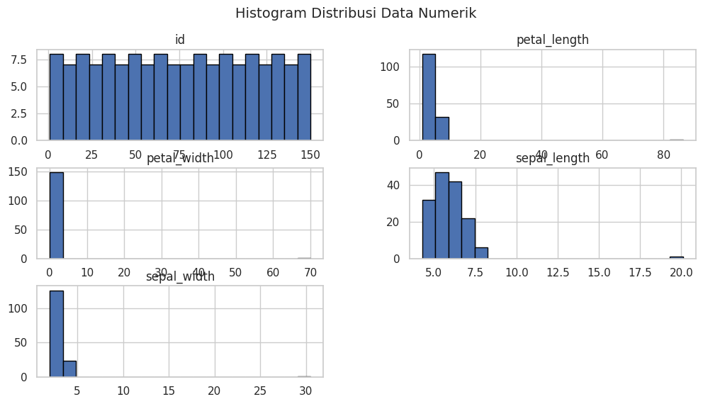

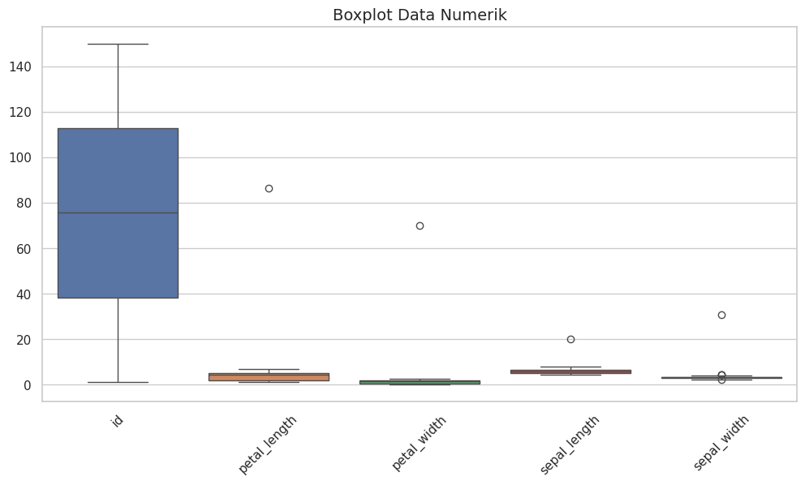

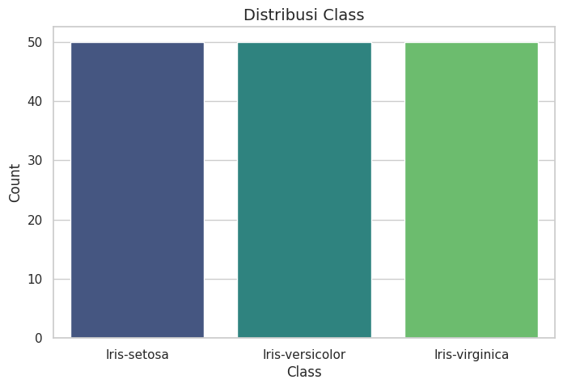

```python
import pandas as pd
import matplotlib.pyplot as plt
import seaborn as sns

# Baca data gabungan dari file CSV yang telah digabung sebelumnya
df_combined = pd.read_csv("combined_iris.csv")

# Pisahkan kolom numerik dan non-numerik
numeric_columns = df_combined.select_dtypes(include=["number"])
non_numeric_columns = df_combined.select_dtypes(exclude=["number"])

# Hitung berbagai statistik deskriptif
feature_stats = pd.DataFrame()

feature_stats["Mean"] = numeric_columns.mean()
feature_stats["Median"] = numeric_columns.median()
feature_stats["Mode"] = numeric_columns.mode().iloc[0]  # Mode bisa lebih dari satu nilai, ambil yang pertama
feature_stats["Standard Deviation"] = numeric_columns.std()
feature_stats["Variance"] = numeric_columns.var()
feature_stats["Min"] = numeric_columns.min()
feature_stats["Max"] = numeric_columns.max()
feature_stats["Missing Values"] = numeric_columns.isnull().sum()

# Print hasil statistik
print("=== Statistik Data Numerik ===")
print(feature_stats.to_string())

# Statistik untuk kolom Class
class_counts = df_combined["Class"].value_counts()
print("\n=== Distribusi Class ===")
print(class_counts)

# ====== GRAFIK VISUALISASI ======

# 1. Histogram untuk distribusi data numerik
plt.figure(figsize=(12, 6))
numeric_columns.hist(figsize=(12, 6), bins=20, edgecolor='black')
plt.suptitle("Histogram Distribusi Data Numerik", fontsize=14)
plt.show()

# 2. Boxplot untuk melihat outlier
plt.figure(figsize=(12, 6))
sns.boxplot(data=numeric_columns)
plt.title("Boxplot Data Numerik", fontsize=14)
plt.xticks(rotation=45)
plt.show()

# 3. Barplot untuk distribusi class
plt.figure(figsize=(8, 5))
sns.barplot(x=class_counts.index, y=class_counts.values, palette="viridis")
plt.title("Distribusi Class", fontsize=14)
plt.xlabel("Class")
plt.ylabel("Count")
plt.show()
```